# Statistics_basic_day5

## PHASE 1

## *TASK1*

'''Write a function normal_pdf(mean, std, x) that returns the pdf value. Find pdf at x = 5 for mean = 5 and std = 1.'''

```python
# one using math
import math
def normal_pdf(mean, std, x):
    return (1 / (std* math.sqrt(2*math.pi))) * math.exp(-((x-mean) **2 / 2 * std**2))
#Given in question
# mean = 5
# std = 1
# x = 5
result = normal_pdf(5, 1, 5)
# printing the answer
print("The pdf at x = 5 for mean = 5 and std = 1 is", result)
```

```
The pdf at x = 5 for mean = 5 and std = 1 is 0.3989422804014327
```

```python
# one without using math only python
def normal_pdf(mean, std, x):
    pi = 3.141592653589793
    e = 2.718281828459045

    exponent =  (-((x-mean) **2 / 2 * std**2))
    return (1/ (std * (2 * pi)**0.5)) * (e ** exponent )

# calling function
result = normal_pdf(5, 1, 5)
print("The pdf at x = 5 for mean = 5 and std = 1 is", result)
```

```
The pdf at x = 5 for mean = 5 and std = 1 is 0.3989422804014327
```

## TASK 2

Task 2 Create a function z_score(x, mean, std). Calculate the z-score of x = 20 when mean = 15 and std = 2.

```python
def z_score(x, mean, std):
    return (x-mean) / std
# calling function
result = z_score(20,15,2)
print("The z-score of x = 20 when mean = 15 and std = 2 is ", result)
```

```
The z-score of x = 20 when mean = 15 and std = 2 is  2.5
```

## TASK 3

Task 3 - Write a simple binomial_prob(n, k, p) function. Find the probability of 2 successes out of 5 trials when p = 0.5.

```python
def factorial(n):
        result = 1
        for i in range(1,n+1):
            result *= i
        return result

def combination(n,k):
    return factorial(n) // (factorial(n-k) * factorial(k))

def  binomial_prob(n, k, p):
    return combination(n,k) * (p**k) * ((1-p)**(n-k))

final = binomial_prob(5,2,0.5)
print("The probability of 2 successes out of 5 trials when p = 0.5 is ",final)
```

```
The probability of 2 successes out of 5 trials when p = 0.5 is  0.3125
```

## TASK 4

Write a function poisson_prob(lmbda, k). Find P(X = 0) for lambda = 3.

```python
def factorial(n):
    result = 1
    for i in range(1,n+1):
        result *= i
    return result

def poisson_prob(lmbda, k):
    e  = 2.718281828459045
    numerator = (lmbda**k) * (e **(-lmbda))
    denominator = factorial(k)
    return numerator / denominator
#Given k = 0 in question so
final = poisson_prob(3,0)
print("P(X = 0) for lambda = 3 is ",final)
```

```
P(X = 0) for lambda = 3 is  0.04978706836786395
```

## PHASE 2

## TASK 1

Task 1 - Generate 3000 values from a normal distribution (mean = 40, std = 6). Compute the sample mean and compare it with the true mean.

```python
import random

values = [ random.gauss(40,6) for _ in range(3000)]

sample_mean = sum(values) / len(values)

print("The sample mean is", sample_mean)
print("True mean is  40")
```

```
The sample mean is 40.043671132662666
True mean is  40
```

## TASK 2

Task 2 - Simulate 1500 samples from a binomial distribution (n = 10, p = 0.3). Plot a histogram and explain the observed shape.

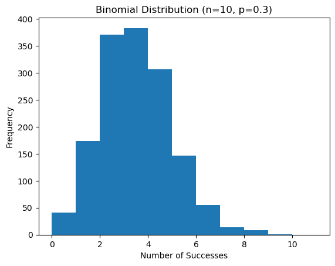

```python
import random
import matplotlib.pyplot as plt

# Task 2: Simulate Binomial samples
n = 10
p = 0.3
samples = []

for _ in range(1500):
    count = 0
    for _ in range(n):
        if random.random() < p:
            count += 1
    samples.append(count)

# Plot histogram
plt.hist(samples, bins=range(0, 12))
plt.xlabel("Number of Successes")
plt.ylabel("Frequency")
plt.title("Binomial Distribution (n=10, p=0.3)")
plt.show()
```

## TASK 3

Task 3 - Simulate 2000 events using a Poisson distribution with lambda = 5. Find the most common outcome (mode). Explain why it is close to lambda.

```python
import random

# Parameters
lambda_val = 5
num_events = 2000

# Function to generate a Poisson random variable using inverse transform method
def poisson_sample(lam):
    L = 2.718281828459045 ** (-lam)  # e^-lambda
    k = 0
    p = 1.0
    while p > L:
        p *= random.random()
        k += 1
    return k - 1  # subtract 1 because loop adds extra 1

# Generate 2000 samples
samples = [poisson_sample(lambda_val) for _ in range(num_events)]

# Find the mode
mode_count = {}
for value in samples:
    if value in mode_count:
        mode_count[value] += 1
    else:
        mode_count[value] = 1

most_common = max(mode_count, key=mode_count.get)

print("Most common outcome (mode) is:", most_common)
print("Lambda (mean) is:", lambda_val)
print(samples[1:15])
```

```
Most common outcome (mode) is: 4
Lambda (mean) is: 5
[6, 3, 3, 2, 1, 8, 4, 3, 3, 7, 5, 4, 3, 4]
```

- Compute L=e^{-\lambda }. - Set k=0. - Set p=1. - Repeat: - Generate a uniform random number u in [0,1]. - Update p=p dot u. - Continue until p <= L. - Increase k by 1. - Return k-1. The loop which i used i think it came from this algorithm.

## TASK 4

Task 4 - Given dataset [10, 12, 15, 18, 25, 30], compute the z-score of 30. Interpret what a high z-score means.

```python
data = [10, 12, 15, 18, 25, 30]

# Calculate mean
mean = sum(data) / len(data)

# Calculate standard deviation (sample)
variance = sum((x - mean)**2 for x in data) / (len(data) - 1)
std = variance**0.5

# Calculate Z-score of 30
x = 30
z_score = (x - mean) / std

print("Mean =", mean)
print("Standard Deviation =", std)
print("Z-score of 30 =", z_score)

# Interpretation
if z_score > 0:
    print("30 is above average value in dataset.")
```

```
Mean = 18.333333333333332
Standard Deviation = 7.7631608682718065
Z-score of 30 = 1.5028242831278387
30 is above average value in dataset.
```

## TASK 5

Plot a normal distribution curve for x = -4 to 4 using normal_pdf(mean=0, std=1). Mark the point where the curve peaks.

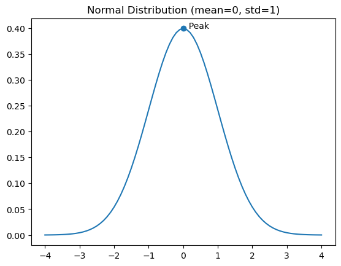

```python
import math
import matplotlib.pyplot as plt

# Normal PDF function
def normal_pdf(x):
    return (1 / math.sqrt(2*math.pi)) * math.exp(-x*x/2)

# Generate x values
x = [i/10 for i in range(-40, 41)]   # from -4 to 4
y = [normal_pdf(i) for i in x]       # PDF values

plt.plot(x, y)                       # plot curve

# Mark the peak
plt.scatter(0, normal_pdf(0))        # peak at x = 0
plt.text(0, normal_pdf(0), "  Peak")

plt.title("Normal Distribution (mean=0, std=1)")
plt.show()
```

## PHASE 3

## TASK 1

''' Task 1 - Generate 2000 values from a normal distribution (mean = 60, std = 10). Convert all values into z-scores. Verify how many fall between -1.96 and +1.96. Explain the 95 percent rule. '''

```python
import random
import math

# Step 1: Generate 2000 values from Normal(mean=60, std=10)
values = []
mean = 60
std = 10

for _ in range(2000):
    # Box-Muller method to generate normal value
    u1 = random.random()
    u2 = random.random()
    z = math.sqrt(-2 * math.log(u1)) * math.cos(2 * math.pi * u2)

    x = mean + std * z      # convert z to actual normal value
    values.append(x)

# Step 2: Convert each value to a z-score
z_scores = []
for x in values:
    z_value = (x - mean) / std
    z_scores.append(z_value)

# Step 3: Count how many z-scores fall between -1.96 and +1.96
count = 0
for z in z_scores:
    if -1.96 <= z <= 1.96:
        count += 1

print("Total values:", len(z_scores))
print("Values between -1.96 and +1.96:", count)
print("Below is explanation of 95 % Rule")
```

```
Total values: 2000
Values between -1.96 and +1.96: 1912
Below is explanation of 95 % Rule
```

*In a normal distribution, almost all values fall near the mean.

- 68% of values fall within ±1 standard deviation
- 95% of values fall within ±2 standard deviations (approx ±1.96)
- 99.7% fall within ±3 standard deviations

So: About 95% of z-scores are between -1.96 and +1.96*

## TASK 2

Task 2 - Simulate 2000 samples from: • Normal distribution (mean = 20, std = 4) • Poisson distribution (lambda = 20) Plot both histograms on the same graph. Explain why Poisson becomes similar to Normal for large lambda.

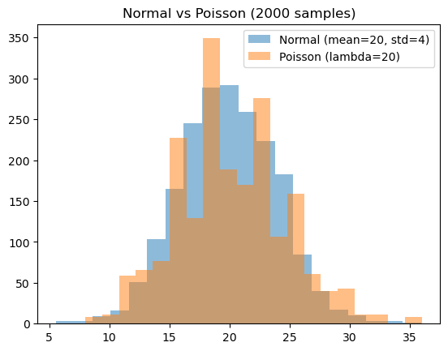

```python
import math
import random
import matplotlib.pyplot as plt

mean = 20
std = 4
lam = 20
n = 2000

# ---------------------------
# 1. Generate Normal samples
# ---------------------------
normal_samples = []
for _ in range(n):
    u1 = random.random()
    u2 = random.random()
    z = math.sqrt(-2 * math.log(u1)) * math.cos(2 * math.pi * u2)
    x = mean + std * z
    normal_samples.append(x)

# ---------------------------
# 2. Generate Poisson samples (Inverse Transform Method)
# ---------------------------
poisson_samples = []

for _ in range(n):
    L = math.exp(-lam)
    p = 1
    k = 0
    while p > L:
        p *= random.random()
        k += 1
    poisson_samples.append(k - 1)

# ---------------------------
# 3. Plot both histograms on SAME graph
# ---------------------------
plt.hist(normal_samples, bins=20, alpha=0.5, label="Normal (mean=20, std=4)")
plt.hist(poisson_samples, bins=20, alpha=0.5, label="Poisson (lambda=20)")
plt.legend()
plt.title("Normal vs Poisson (2000 samples)")
plt.show()
```

**Explain why Poisson becomes similar to Normal for large lambda.**

- When λ is large, the Poisson distribution becomes similar to a Normal distribution because it can be viewed as the sum of many small, independent rare events. According to the Central Limit Theorem, such sums tend to follow a Normal distribution. As λ increases, the Poisson distribution becomes less skewed, more symmetric, and more spread out, making its shape closely resemble the bell curve. Thus, for large λ(typically λ ≥ 15–20), Poisson(λ) can be well-approximated by Normal(λ, λ).

## TASK 3

Task 3 - Write a function simulate_binomial_estimation(n, p, trials) that simulates binomial outcomes. Run with n=20, p=0.4, trials=5000. Compare the empirical probability of k=8 with the theoretical value.

```python
import random
import math

# factorial
def factorial(n):
    result = 1
    for i in range(1, n+1):
        result *= i
    return result

# combination formula
def combination(n, k):
    return factorial(n) / (factorial(k) * factorial(n-k))

# theoretical probability for binomial
def binomial_theoretical(n, p, k):
    return combination(n, k) * (p**k) * ((1-p)**(n-k))

# simulation function
def simulate_binomial_estimation(n, p, trials):
    count_k8 = 0

    for _ in range(trials):
        success = 0
        for _ in range(n):
            if random.random() < p:
                success += 1
        if success == 8:
            count_k8 += 1

    return count_k8 / trials  # empirical probability

# Given values
n = 20
p = 0.4
trials = 5000
k = 8

empirical = simulate_binomial_estimation(n, p, trials)
theoretical = binomial_theoretical(n, p, k)

print("Empirical Probability of k=8:", empirical)
print("Theoretical Probability of k=8:", theoretical)
```

```
Empirical Probability of k=8: 0.189
Theoretical Probability of k=8: 0.17970578775468934
```

## TASK 4

Task 4 - Generate two normal distributions: • N1 mean=30, std=3 • N2 mean=30, std=10 Plot both curves on same graph. Explain how standard deviation affects the shape.

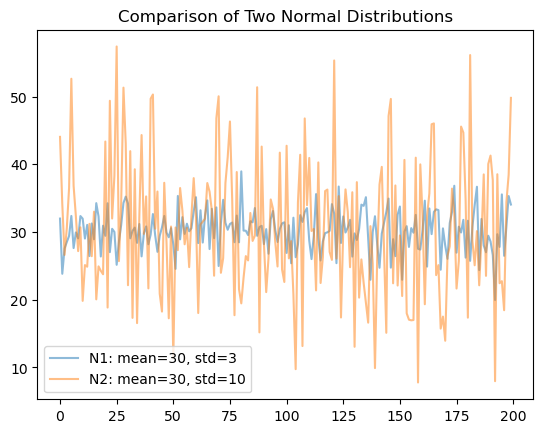

```python
import random
import math
import matplotlib.pyplot as plt

# Function to generate normal samples using Box-Muller
def normal_distribution(mean, std, size=200):
    samples = []
    for _ in range(size):
        u1 = random.random()
        u2 = random.random()
        z = math.sqrt(-2 * math.log(u1)) * math.cos(2 * math.pi * u2)
        x = mean + std * z
        samples.append(x)
    return samples

# Generate two distributions
N1 = normal_distribution(30, 3)
N2 = normal_distribution(30, 10)

# Plot both curves
plt.plot(N1, alpha=0.5, label="N1: mean=30, std=3")
plt.plot(N2, alpha=0.5, label="N2: mean=30, std=10")
plt.legend()
plt.title("Comparison of Two Normal Distributions")
plt.show()
```

**Explanation: How Standard Deviation Affects Shape**

- Standard deviation measures spread of data around the mean.
- Small std (3) → data is closer to mean → narrow, tall peak
- Large std (10) → data is more spread out → wide, shorter peak
- Both still centered at mean=30, but the width changes.

## TASK 5

Task 5 - Use poisson_prob to compute probabilities for k = 0 to 10 when lambda = 4. Plot the probability mass function (PMF). Identify which k has the highest probability.

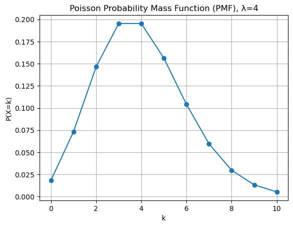

```
Highest probability is at k=3, P=0.1954
```

```python
import math
import matplotlib.pyplot as plt

# factorial function
def factorial(k):
    result = 1
    for i in range(1, k+1):
        result *= i
    return result

# Poisson probability function
def poisson_prob(lmbda):
    samples = []
    for k in range(11):  # 0 to 10 inclusive
        p = (lmbda**k * math.exp(-lmbda)) / factorial(k)
        samples.append(p)
    return samples

lmbda = 4
poisson_samples = poisson_prob(lmbda)
k_values = list(range(11))  # k = 0 to 10

# Plot PMF
plt.plot(k_values, poisson_samples, marker='o')
plt.title("Poisson Probability Mass Function (PMF), λ=4")
plt.xlabel("k")
plt.ylabel("P(X=k)")
plt.grid(True)
plt.show()

# Identify which k has the highest probability
max_prob = max(poisson_samples)
k_max = k_values[poisson_samples.index(max_prob)]
print(f"Highest probability is at k={k_max}, P={max_prob:.4f}")
```

```python
poisson_samples
```

[output not shown]